# Homework 8

Hannah Shafer

3/16/2022

1. In my lab, we are researching devernalization responses in grasses. We hypothesized that grasses that are devernalization-responsive will have delayed flowering time after an interrupted vernalization period (in which they become devernalized). We have a control group of vernalized plants and a group that undergoes devernalization via hot temperatures.
2. For this exercise, I will focus on two treatment groups (control and hot), and look at 60 individuals of the same species in each group. Based on previous literature (https://link.springer.com/article/10.1007/s12155-009-9069-3), I’ll assign a predicted mean of 50 days to flowering for the control group, and a mean of 65 days to flowering for the hot group (~2 weeks later since the vernalization will be interrupted for 2 weeks). The standard deviation will be set at 5 days based on personal observations, and each treatment group will have 60 individuals to mirror my ongoing experiment.
3. Creating a data frame with random values generated based on the above parameters:

```r
# first couple variables, predetermined
ID <- 1:120
Treatment <- rep(c("Control","Hot"),each=60)

# generate the random, normal counts for the two groups
control <- round(rnorm(n=60, mean=50, sd=5))
hot <- round(rnorm(n=60, mean=65, sd=5))

# response variable for data frame:
DaysToFlower <- c(control, hot)

# make the data frame itself
d_frame <- data.frame(ID, Treatment, DaysToFlower)
```

4. Analyzing the data and generating a useful graph; I will use a t-test because my x variable is categorical (control vs. hot) and my y variable is continuous (# of days):

```r
library(ggplot2)
library(dplyr)
# t-test
t.test(control,hot)
```

```
##
##  Welch Two Sample t-test
##
## data:  control and hot
## t = -17.996, df = 114.02, p-value < 2.2e-16
## alternative hypothesis: true difference in means is not equal to 0
## 95 percent confidence interval:
##  -17.44679 -13.98654
## sample estimates:
## mean of x mean of y
##  49.00000  64.71667
```

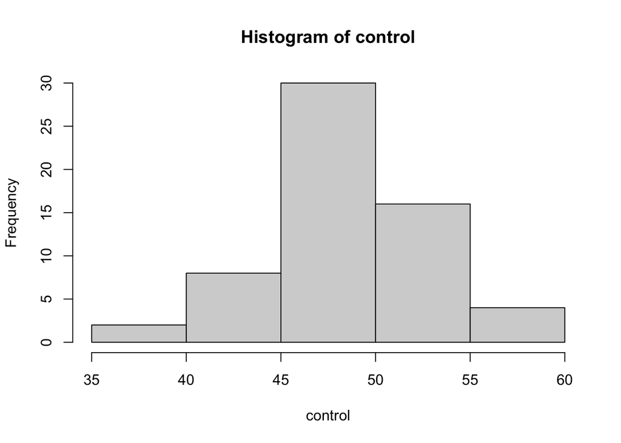

```r
#p-val is less than 2.2e-16, so there is a significant difference between the flowering time of the vernalized plants and devernalized plants

# graphing

# distribution of days to flowering for control
hist(control)
```

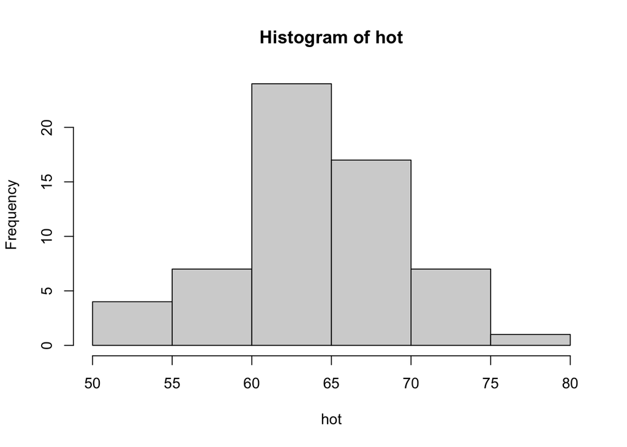

```r
# distribution of days to flowering for hot
hist(hot)
```

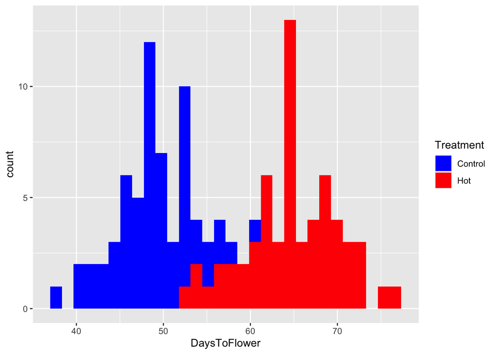

```r
# histogram showing counts for days to flowering for both hot and cold (can see the bimodal pattern better)
graph <- d_frame %>%
  ggplot(aes(x=DaysToFlower, fill=Treatment)) +
    geom_histogram() +
  scale_fill_manual(values=c("blue", "red"))
print(graph)
```

5. Running the above analysis a few more times to get a feel for the results with the same parameters but given different random counts: From this exercise, I saw variation in the counts themselves, and the graphs had varying degrees of bimodality based on treatment group. However, the p-values for the t-tests remained significant (and even had the same value), and I continued to see a clear separation between the treatment groups.
6. Adjusting means: seeing what the smallest difference between means can be to still get a significant difference between treatment groups. Here, I simply adjusted the mean of the control group, increasing by 1 until I reached the point of no significant difference.

```r
control_adjusted <- round(rnorm(n=60, mean=61, sd=5))
hot_adjusted <- round(rnorm(n=60, mean=65, sd=5))
DaysToFlower_adjusted <- c(control_adjusted, hot_adjusted)
d_frame_adjusted <- data.frame(ID, Treatment, DaysToFlower)
t.test(control_adjusted,hot_adjusted)
```

```
##
##  Welch Two Sample t-test
##
## data:  control_adjusted and hot_adjusted
## t = -5.1081, df = 117.98, p-value = 1.266e-06
## alternative hypothesis: true difference in means is not equal to 0
## 95 percent confidence interval:
##  -6.475821 -2.857512
## sample estimates:
## mean of x mean of y
##  60.48333  65.15000
```

After running the above script a few times, I found that a difference of 4 (means of 61 and 65) consistently yielded a significant p-value. A difference of 3 (means of 62 and 65) often yielded a significant p-value, but occasionally yielded a p-value higher than 0.05.

7. Adjusting sample sizes: seeing what the minimum sample size is to still see a significant effect with the original means. Here I decreased the sample size in increments for both treatment groups equally.

```r
control_adjusted <- round(rnorm(n=3, mean=50, sd=5))
hot_adjusted <- round(rnorm(n=3, mean=65, sd=5))
DaysToFlower_adjusted <- c(control_adjusted, hot_adjusted)
d_frame_adjusted <- data.frame(ID, Treatment, DaysToFlower)
t.test(control_adjusted,hot_adjusted)
```

```
##
##  Welch Two Sample t-test
##
## data:  control_adjusted and hot_adjusted
## t = -2.8483, df = 3.8291, p-value = 0.04892
## alternative hypothesis: true difference in means is not equal to 0
## 95 percent confidence interval:
##  -15.93745497  -0.06254503
## sample estimates:
## mean of x mean of y
##  54.33333  62.33333
```

After running the above script a few times, I found that a sample size of 5 for each treatment group consistently yielded a significant p-value, and a sample size of 4 for each treatment group yielded a significant p-value 9 out of every 10 runs.